# 1. packages importation

## 2.7 creating new dataset censoring observations that died within 2 years for supplementary analysis

```python
dfMortCens=dfMort.copy()
dfMortCens['death']=np.where(dfMortCens['time']<=2,0,dfMortCens['death'])
dfMortCens['death'].value_counts()
dfMortCens.to_csv("/Users/valler/OneDrive - Nexus365/Python_hrsPsyMortCens_20190131b.csv")
```

```
count    13611.000000000
mean         6.372149977
std          1.830479882
min          0.083333333
25%          5.833333333
50%          6.166666667
75%          7.916666667
max          8.583333333
Name: time, dtype: float64
```

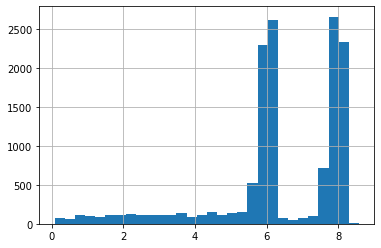

```python
dfMortCens['time'].hist(bins=30)
dfMortCens['time'].describe()
```

```
count    13611.000000000
mean        69.346043641
std          9.665006660
min         52.000000000
25%         62.000000000
50%         69.000000000
75%         76.000000000
max        104.000000000
Name: age, dtype: float64
```

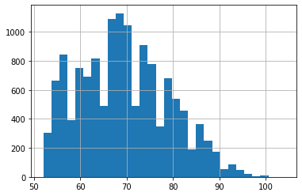

```python
dfMortCens['age'].hist(bins=30)
dfMortCens['age'].describe()
```

Note: the result so far is identical to the result obtained from R

# 3. ANALYSIS 1 - Cox models (age as baseline hazard)

## 3.1 Domain 1:DEMOGRAPHICS (D)

```python
m='d1 <- coxph(Surv(age,death) ~ maleYN + cluster(hhid), data=hrsPsyMort, weights=sampWeight)d2 <- coxph(Surv(age,death) ~ blackYN + cluster(hhid), data=hrsPsyMort, weights=sampWeight)d3 <- coxph(Surv(age,death) ~ otherYN + cluster(hhid), data=hrsPsyMort, weights=sampWeight)d4 <- coxph(Surv(age,death) ~ hispanicYN + cluster(hhid), data=hrsPsyMort, weights=sampWeight)d5 <- coxph(Surv(age,death) ~ migrantYN + cluster(hhid), data=hrsPsyMort, weights=sampWeight)'
domain1=re.findall(r'~ (\w*) +',str(m))
res={}
for column in domain1:
    data=dfMort[[column,'age','death','sampWeight','hhid']]
    cph = CoxPHFitter()
    cph.fit(data, duration_col='age', event_col='death',weights_col='sampWeight',cluster_col='hhid')
    res[column]=cph
```

```python
coef=pd.DataFrame()
for column in domain1:
    temp=pd.DataFrame(res[column].summary).iloc[0]
    coef=pd.concat([coef,temp],axis=1)
coef=coef.T
coef['log p value']=np.log(coef['p'])
coef_1=coef
```

```python
coef_1
```

|  | coef | exp(coef) | se(coef) | coef lower 95% | coef upper 95% | exp(coef) lower 95% | exp(coef) upper 95% | z | p | -log2(p) | log p value |
| --- | --- | --- | --- | --- | --- | --- | --- | --- | --- | --- | --- |
| maleYN | 0.245368313 | 1.278091965 | 0.021287751 | 0.203645089 | 0.287091538 | 1.225863004 | 1.332546186 | 11.526267742 | 9.726980808e-31 | 99.697778870 | -69.105234332 |
| blackYN | 0.196850939 | 1.217562536 | 0.036683968 | 0.124951682 | 0.268750196 | 1.133093703 | 1.308328275 | 5.366129872 | 8.044402838e-08 | 23.567439430 | -16.335704194 |
| otherYN | 0.073854782 | 1.076650445 | 0.069939717 | -0.063224545 | 0.210934109 | 0.938732662 | 1.234830988 | 1.055977700 | 2.909784032e-01 | 1.781016017 | -1.234506231 |
| hispanicYN | 0.015757705 | 1.015882512 | 0.050915442 | -0.084034728 | 0.115550138 | 0.919399326 | 1.122490793 | 0.309487736 | 7.569505400e-01 | 0.401729059 | -0.278457365 |
| migrantYN | -0.136483704 | 0.872420538 | 0.043931182 | -0.222587238 | -0.050380169 | 0.800445175 | 0.950867865 | -3.106761475 | 1.891489499e-03 | 9.046261518 | -6.270390665 |

## 3.2 Domain 2: Childhood SES and PSYCH ADVERSITY (c)

### 3.2.1 model fitting

```python
domain2=['fathersocc','Zfatherseduc','Zmotherseduc','fatherunemp','relocate','finhelp','sumCAE']
res={}

for column in domain2:
    data=dfMort[[column,'age','death','sampWeight','hhid','maleYN','blackYN','hispanicYN','otherYN','migrantYN']]
    cph = CoxPHFitter()
    cph.fit(data, duration_col='age', event_col='death',weights_col='sampWeight',cluster_col='hhid')
    res[column]=cph
```

[output not shown]

### 3.2.2 store coefficients

```python
coef=pd.DataFrame()
for column in domain2:
    temp=pd.DataFrame(res[column].summary).iloc[0]
    coef=pd.concat([coef,temp],axis=1)
coef=coef.T
coef['log p value']=np.log(coef['p'])
coef_2=coef
```

## 3.3 Domain 3: Adulthood Socioeconomic (e)

### 3.3.1 topcoding top 1% of wealth and income due to sparse data and skew

```python
#dfMort['Zincome'].quantile(q=(0.5,.6,.7,.8,.9,.95,.99,1))
dfMort['ZincomeT']=np.where(dfMort['Zincome']>=1.80427,1.80427,dfMort['Zincome'])
dfMort['ZincomeT'].quantile(q=(0.5,.6,.7,.8,.9,.95,.99,1))
```

```
0.50    0.140038621
0.60    0.183216883
0.70    0.218757088
0.80    0.253286498
0.90    0.283008521
0.95    0.297584353
0.99    0.329218133
1.00    0.341945580
Name: ZincomeT, dtype: float64
```

```python
dfMort['ZwealthT']=np.where(dfMort['Zwealth']>=3.49577,3.49577,dfMort['Zwealth'])
dfMort['ZwealthT'].quantile(q=(0.5,.6,.7,.8,.9,.95,.99,1))
```

```
0.50    0.225290977
0.60    0.282879519
0.70    0.329490246
0.80    0.367262731
0.90    0.392937623
0.95    0.394857241
0.99    0.410543405
1.00    2.154020845
Name: ZwealthT, dtype: float64
```

#### question: this step makes no sense since there is no data bigger than 1.840427 in `Zincome` and no data bigger than 3.49577 in column `Zwealth`

```python
print(dfMort['Zincome'].max(),dfMort['Zwealth'].max())
```

```
0.34194558 2.154020845
```

### 3.3.2 model fitting

```python
domain3=['ZwealthT','ZincomeT','everrent','evermedicaid','everfoodstamp','everunemployed','everfoodinsec','Zeduccat','Zrecentfindiff','Zneighsafety','Zneighcohesion','Zneighdisorder','rocc']
res={}

for column in domain3:
    data=dfMort[[column,'age','death','sampWeight','hhid','maleYN','blackYN','hispanicYN','otherYN','migrantYN']]
    cph = CoxPHFitter()
    cph.fit(data, duration_col='age', event_col='death',weights_col='sampWeight',cluster_col='hhid')
    res[column]=cph
```

[output not shown]

[output cut: 10 more lines]

[output not shown]

### 3.3.3 store coefficients

```python
coef=pd.DataFrame()
for column in domain3:
    temp=pd.DataFrame(res[column].summary).iloc[0]
    coef=pd.concat([coef,temp],axis=1)
coef=coef.T
coef['log p value']=np.log(coef['p'])
coef_3=coef
```

## 3.4 Domain 4: Health Behaviors (b)

### 3.4.1 model fitting¶

```python
m='d1 <- coxph(Surv(age,death) ~ vigactivityYN + maleYN + blackYN + hispanicYN + otherYN + migrantYN + cluster(hhid), data=hrsPsyMort, weights=sampWeight)d2 <- coxph(Surv(age,death) ~ modactivityYN + maleYN + blackYN + hispanicYN + otherYN + migrantYN + cluster(hhid), data=hrsPsyMort, weights=sampWeight)d3 <- coxph(Surv(age,death) ~ alcoholYN + maleYN + blackYN + hispanicYN + otherYN + migrantYN + cluster(hhid), data=hrsPsyMort, weights=sampWeight)d4 <- coxph(Surv(age,death) ~ sleepYN + maleYN + blackYN + hispanicYN + otherYN + migrantYN + cluster(hhid), data=hrsPsyMort, weights=sampWeight)d5 <- coxph(Surv(age,death) ~ eversmokeYN + maleYN + blackYN + hispanicYN + otherYN + migrantYN + cluster(hhid), data=hrsPsyMort, weights=sampWeight)d6 <- coxph(Surv(age,death) ~ currsmokeYN + maleYN + blackYN + hispanicYN + otherYN + migrantYN + cluster(hhid), data=hrsPsyMort, weights=sampWeight)'
domain4=re.findall(r'~ (\w*) +',str(m))

res={}

for column in domain4:
    data=dfMort[[column,'age','death','sampWeight','hhid','maleYN','blackYN','hispanicYN','otherYN','migrantYN']]
    cph = CoxPHFitter()
    cph.fit(data, duration_col='age', event_col='death',weights_col='sampWeight',cluster_col='hhid')
    res[column]=cph
```

### 3.4.2 store coefficients

```python
coef=pd.DataFrame()
for column in domain4:
    temp=pd.DataFrame(res[column].summary).iloc[0]
    coef=pd.concat([coef,temp],axis=1)
coef=coef.T
coef['log p value']=np.log(coef['p'])
coef_4=coef
```

## 3.5 Domain 5: Adulthood Adverse Experiences (a)

### 3.5.1 model fitting

```python
m='d1 <- coxph(Surv(age,death) ~ sumadultAE + maleYN + blackYN + hispanicYN + otherYN + migrantYN + cluster(hhid), data=hrsPsyMort, weights=sampWeight)d2 <- coxph(Surv(age,death) ~ Zmajdiscrim + maleYN + blackYN + hispanicYN + otherYN + migrantYN + cluster(hhid), data=hrsPsyMort, weights=sampWeight)d3 <- coxph(Surv(age,death) ~ Zdailydiscrim + maleYN + blackYN + hispanicYN + otherYN + migrantYN + cluster(hhid), data=hrsPsyMort, weights=sampWeight)'
domain5=re.findall(r'~ (\w*) +',str(m))

res={}

for column in domain5:
    data=dfMort[[column,'age','death','sampWeight','hhid','maleYN','blackYN','hispanicYN','otherYN','migrantYN']]
    cph = CoxPHFitter()
    cph.fit(data, duration_col='age', event_col='death',weights_col='sampWeight',cluster_col='hhid')
    res[column]=cph
```

### 3.5.2 store

```python
coef=pd.DataFrame()
for column in domain5:
    temp=pd.DataFrame(res[column].summary).iloc[0]
    coef=pd.concat([coef,temp],axis=1)
coef=coef.T
coef['log p value']=np.log(coef['p'])
coef_5=coef
```

## 3.6 Domain 6: Social Connections (s)

### 3.6.1 model fitting¶

```python
m='d1 <- coxph(Surv(age,death) ~ Znegchildren + maleYN + blackYN + hispanicYN + otherYN + migrantYN + cluster(hhid), data=hrsPsyMort, weights=sampWeight)d2 <- coxph(Surv(age,death) ~ Znegfamily + maleYN + blackYN + hispanicYN + otherYN + migrantYN + cluster(hhid), data=hrsPsyMort, weights=sampWeight)d3 <- coxph(Surv(age,death) ~ Znegfriends + maleYN + blackYN + hispanicYN + otherYN + migrantYN + cluster(hhid), data=hrsPsyMort, weights=sampWeight)d4 <- coxph(Surv(age,death) ~ Zposchildren + maleYN + blackYN + hispanicYN + otherYN + migrantYN + cluster(hhid), data=hrsPsyMort, weights=sampWeight)d5 <- coxph(Surv(age,death) ~ Zposfamily + maleYN + blackYN + hispanicYN + otherYN + migrantYN + cluster(hhid), data=hrsPsyMort, weights=sampWeight)d6 <- coxph(Surv(age,death) ~ everdivorced + maleYN + blackYN + hispanicYN + otherYN + migrantYN + cluster(hhid), data=hrsPsyMort, weights=sampWeight)d7 <- coxph(Surv(age,death) ~ nevermarried + maleYN + blackYN + hispanicYN + otherYN + migrantYN + cluster(hhid), data=hrsPsyMort, weights=sampWeight)d8 <- coxph(Surv(age,death) ~ Zposfriends + maleYN + blackYN + hispanicYN + otherYN + migrantYN + cluster(hhid), data=hrsPsyMort, weights=sampWeight)'
domain6=re.findall(r'~ (\w*) +',str(m))

res={}

for column in domain6:
    data=dfMort[[column,'age','death','sampWeight','hhid','maleYN','blackYN','hispanicYN','otherYN','migrantYN']]
    cph = CoxPHFitter()
    cph.fit(data, duration_col='age', event_col='death',weights_col='sampWeight',cluster_col='hhid')
    res[column]=cph
```

[output not shown]

```python
#store
coef=pd.DataFrame()
for column in domain6:
    temp=pd.DataFrame(res[column].summary).iloc[0]
    coef=pd.concat([coef,temp],axis=1)
coef=coef.T
coef['log p value']=np.log(coef['p'])
coef_6=coef
```

## 3.7 Domain7: Psychological (d)

```python
m='d1 <- coxph(Surv(age,death) ~ Zagreeableness + maleYN + blackYN + hispanicYN + otherYN + migrantYN + cluster(hhid), data=hrsPsyMort, weights=sampWeight)d2 <- coxph(Surv(age,death) ~ Zangerin + maleYN + blackYN + hispanicYN + otherYN + migrantYN + cluster(hhid), data=hrsPsyMort, weights=sampWeight)d3 <- coxph(Surv(age,death) ~ Zangerout + maleYN + blackYN + hispanicYN + otherYN + migrantYN + cluster(hhid), data=hrsPsyMort, weights=sampWeight)d4 <- coxph(Surv(age,death) ~ Zanxiety + maleYN + blackYN + hispanicYN + otherYN + migrantYN + cluster(hhid), data=hrsPsyMort, weights=sampWeight)d5 <- coxph(Surv(age,death) ~ Zconscientiousness + maleYN + blackYN + hispanicYN + otherYN + migrantYN + cluster(hhid), data=hrsPsyMort, weights=sampWeight)d6 <- coxph(Surv(age,death) ~ Zcynhostility + maleYN + blackYN + hispanicYN + otherYN + migrantYN + cluster(hhid), data=hrsPsyMort, weights=sampWeight)d7 <- coxph(Surv(age,death) ~ Zextroversion + maleYN + blackYN + hispanicYN + otherYN + migrantYN + cluster(hhid), data=hrsPsyMort, weights=sampWeight)d8 <- coxph(Surv(age,death) ~ Zhopelessness + maleYN + blackYN + hispanicYN + otherYN + migrantYN + cluster(hhid), data=hrsPsyMort, weights=sampWeight)d9 <- coxph(Surv(age,death) ~ Zlifesatis + maleYN + blackYN + hispanicYN + otherYN + migrantYN + cluster(hhid), data=hrsPsyMort, weights=sampWeight)d10 <- coxph(Surv(age,death) ~ Zloneliness + maleYN + blackYN + hispanicYN + otherYN + migrantYN + cluster(hhid), data=hrsPsyMort, weights=sampWeight)d11 <- coxph(Surv(age,death) ~ Znegaffect + maleYN + blackYN + hispanicYN + otherYN + migrantYN + cluster(hhid), data=hrsPsyMort, weights=sampWeight)d12 <- coxph(Surv(age,death) ~ Zneuroticism + maleYN + blackYN + hispanicYN + otherYN + migrantYN + cluster(hhid), data=hrsPsyMort, weights=sampWeight)d13 <- coxph(Surv(age,death) ~ Zopenness + maleYN + blackYN + hispanicYN + otherYN + migrantYN + cluster(hhid), data=hrsPsyMort, weights=sampWeight)d14 <- coxph(Surv(age,death) ~ Zoptimism + maleYN + blackYN + hispanicYN + otherYN + migrantYN + cluster(hhid), data=hrsPsyMort, weights=sampWeight)d15 <- coxph(Surv(age,death) ~ Zperceivedconstraints + maleYN + blackYN + hispanicYN + otherYN + migrantYN + cluster(hhid), data=hrsPsyMort, weights=sampWeight)d16 <- coxph(Surv(age,death) ~ Zperceivedmastery + maleYN + blackYN + hispanicYN + otherYN + migrantYN + cluster(hhid), data=hrsPsyMort, weights=sampWeight)d17 <- coxph(Surv(age,death) ~ Zpessimism + maleYN + blackYN + hispanicYN + otherYN + migrantYN + cluster(hhid), data=hrsPsyMort, weights=sampWeight)d18 <- coxph(Surv(age,death) ~ Zposaffect + maleYN + blackYN + hispanicYN + otherYN + migrantYN + cluster(hhid), data=hrsPsyMort, weights=sampWeight)d19 <- coxph(Surv(age,death) ~ Zpurpose + maleYN + blackYN + hispanicYN + otherYN + migrantYN + cluster(hhid), data=hrsPsyMort, weights=sampWeight)d20 <- coxph(Surv(age,death) ~ Zreligiosity + maleYN + blackYN + hispanicYN + otherYN + migrantYN + cluster(hhid), data=hrsPsyMort, weights=sampWeight)'
domain7=re.findall(r'~ (\w*) +',str(m))

res={}

for column in domain7:
    data=dfMort[[column,'age','death','sampWeight','hhid','maleYN','blackYN','hispanicYN','otherYN','migrantYN']]
    cph = CoxPHFitter()
    cph.fit(data, duration_col='age', event_col='death',weights_col='sampWeight',cluster_col='hhid')
    res[column]=cph
```

[output not shown]

[output cut: 45 more lines]

[output not shown]

```python
#store
coef=pd.DataFrame()
for column in domain7:
    temp=pd.DataFrame(res[column].summary).iloc[0]
    coef=pd.concat([coef,temp],axis=1)
coef=coef.T
coef['log p value']=np.log(coef['p'])
coef_7=coef
```

#### Store all coefficients into one df

2->c 3->e 4->b 5->a 6->s 7->d

```python
#store coef,ul,ll
coef=coef_2.copy()
coef['UL']=0
coef['LL']=0
for index,row in coef.iterrows():
    coef.loc[index,'UL']= coef.loc[index,'coef']+3.327213*coef.loc[index,'se(coef)']
    coef.loc[index,'LL']= coef.loc[index,'coef']-3.327213*coef.loc[index,'se(coef)']
coef[['coef','LL','UL']]
c_cci=coef

coef=coef_3.copy()
coef['UL']=0
coef['LL']=0
for index,row in coef.iterrows():
    coef.loc[index,'UL']= coef.loc[index,'coef']+3.327213*coef.loc[index,'se(coef)']
    coef.loc[index,'LL']= coef.loc[index,'coef']-3.327213*coef.loc[index,'se(coef)']
coef[['coef','LL','UL']]
e_cci=coef

coef=coef_4.copy()
coef['UL']=0
coef['LL']=0
for index,row in coef.iterrows():
    coef.loc[index,'UL']= coef.loc[index,'coef']+3.327213*coef.loc[index,'se(coef)']
    coef.loc[index,'LL']= coef.loc[index,'coef']-3.327213*coef.loc[index,'se(coef)']
coef[['coef','LL','UL']]
b_cci=coef

coef=coef_5.copy()
coef['UL']=0
coef['LL']=0
for index,row in coef.iterrows():
    coef.loc[index,'UL']= coef.loc[index,'coef']+3.327213*coef.loc[index,'se(coef)']
    coef.loc[index,'LL']= coef.loc[index,'coef']-3.327213*coef.loc[index,'se(coef)']
coef[['coef','LL','UL']]
a_cci=coef

coef=coef_6.copy()
coef['UL']=0
coef['LL']=0
for index,row in coef.iterrows():
    coef.loc[index,'UL']= coef.loc[index,'coef']+3.327213*coef.loc[index,'se(coef)']
    coef.loc[index,'LL']= coef.loc[index,'coef']-3.327213*coef.loc[index,'se(coef)']
coef[['coef','LL','UL']]
s_cci=coef


coef=coef_7.copy()
coef['UL']=0
coef['LL']=0
for index,row in coef.iterrows():
    coef.loc[index,'UL']= coef.loc[index,'coef']+3.327213*coef.loc[index,'se(coef)']
    coef.loc[index,'LL']= coef.loc[index,'coef']-3.327213*coef.loc[index,'se(coef)']
coef[['coef','LL','UL']]
d_cci=coef


#store coef,pvalue
all_coef_pval=pd.concat([coef_2[['coef','p','-log2(p)','log p value']],coef_3[['coef','p','-log2(p)','log p value']],coef_4[['coef','p','-log2(p)','log p value']],coef_5[['coef','p','-log2(p)','log p value']],coef_6[['coef','p','-log2(p)','log p value']],coef_7[['coef','p','-log2(p)','log p value']]],axis=0)
```

### 3.8.1 `all_cci_o_t` exponentiated all_cci_o

```python
c_cci['domain']="Childhood Adversity"
e_cci['domain']="Adulthood Socioeconomic"
b_cci['domain']="Adulthood Health Behaviors"
a_cci['domain']="Adulthood Adverse Experiences"
s_cci['domain']="Adulthood Social Connections"
d_cci['domain']="Adulthood Psychological"
```

```python
all_cci=pd.concat([c_cci,e_cci,b_cci,a_cci,s_cci,d_cci],axis=0)
all_cci_o=all_cci.sort_values(by=['coef'],ascending=False)
```

```python
all_cci_o['names']=all_cci_o.index
```

```python
#assign labels
m=["migrantYN", "Zfatherseduc", "Zmotherseduc", "fathersocc", "relocate", "finhelp", "fatherunemp", "sumCAE", "ZwealthT", "ZincomeT", "rocc", "everrent", "evermedicaid", "everfoodstamp", "everunemployed", "everfoodinsec", "Zeduccat", "Zrecentfindiff", "Zneighsafety", "Zneighcohesion", "Zneighdisorder", "vigactivityYN", "modactivityYN", "alcoholYN", "sleepYN", "eversmokeYN", "currsmokeYN", "sumadultAE", "Zmajdiscrim", "Zdailydiscrim", "Znegchildren", "Znegfamily", "Znegfriends", "Zposchildren", "Zposfamily", "Zposfriends", "everdivorced", "nevermarried", "Zagreeableness", "Zangerin", "Zangerout", "Zanxiety", "Zconscientiousness", "Zcynhostility", "Zextroversion", "Zhopelessness", "Zlifesatis", "Zloneliness", "Znegaffect", "Zneuroticism", "Zopenness", "Zoptimism", "Zperceivedconstraints", "Zperceivedmastery", "Zpessimism", "Zposaffect", "Zpurpose", "Zreligiosity"]
label=["Immigrant to USA", "Lower Education Father", "Lower Education Mother", "Lower Father Occupational Status", "Relocated Homes in Childhood", "Family Received Financial Help in Childhood", "Father was Unemployed in Childhood", "Childhood Psychosocial Adversities", "Lower Wealth", "Lower Income", "Lower Occupational Status", "History of Renting", "History of Medicaid", "History of Food Stamps", "History of Unemployment", "History of Food Insecurity", "Lower Education", "Recent Financial Difficulties", "Lower Neighborhood Safety", "Lower Neighborhood Cohesion", "Neighborhood Disorder", "Low/No Vigorous Activity", "Low/No Moderate Activity", "Alcohol Abuse", "Sleep Problems", "History of Smoking", "Current Smoker", "Adulthood Psychosocial Adversity", "Major Discrimination", "Daily Discrimination", "Negative Interactions with Children", "Negative Interactions with Family", "Negative Interactions with Friends", "Lower Positive Interactions with Children", "Lower Positive Interactions with Family", "Lower Positive Interactions with Friends", "History of Divorce", "Never Married", "Lower Agreeableness ", "Anger In", "Anger Out", "Trait Anxiety", "Lower Conscientiousness", "Cynical Hostility", "Lower Extroversion", "Hopelessness", "Lower Life Satisfaction", "Loneliness", "Negative Affectivity", "Lower Neuroticism", "Lower Openness to Experiences", "Lower Optimism", "Perceptions of Obstacles", "Lower Sense of Mastery", "Pessimism", "Lower Positive Affectivity", "Lower Purpose in Life", "Lower Religiosity"]
dict={}
i=0
while i <len(m):
    dict[m[i]]=label[i]
    i=i+1
m=lambda x:dict[x]
all_cci_o['namesLabel']=''
for index,row in all_cci_o[['names']].iterrows():
    all_cci_o.loc[index,'namesLabel']=m(all_cci_o.loc[index,'names'])
```

```python
#all_cci_o.to_csv('/Users/valler/OneDrive - Nexus365/temp data/all_cci_o_04192021.csv')
```

```python
#all_cci_o_t exponentiated all_cci_o
all_cci_o_t=all_cci_o.copy()
#exponentiate columns ['coef','UL','LL']
for column in ['coef','UL','LL']:
    all_cci_o_t[column]=np.exp(all_cci_o_t[column])
```

## 3.8.2 `all_coef_pval`

```python
all_coef_pval['names']=all_coef_pval.index
all_coef_pval['coef']=np.exp(all_coef_pval['coef'])
all_coef_pval=all_coef_pval[['coef','p','names']]
```

```python
all_coef_pval.columns=['coef1','p','names']
all_cci_o_t=all_coef_pval.merge(all_cci_o_t,left_on='names',right_on='names')
all_cci_o_t=all_cci_o_t.sort_values(by=['coef'],ascending=False)
```

### codes for deriving table 1

all_cci_o_t_round=all_cci_o_t.copy() all_cci_o_t_round['coef']=round(all_cci_o_t_round['coef'],2) all_cci_o_t_round['LL']=round(all_cci_o_t_round['LL'],2) all_cci_o_t_round['UL']=round(all_cci_o_t_round['UL'],2) all_cci_o_t_round.sort_values(by=['coef'],ascending=False)

table_1=all_cci_o_t_round[['namesLabel','coef','LL','UL']].sort_values(by=['coef'],ascending=False)

# table_1.to_csv('/Users/valler/OneDrive - Nexus365/table_1_py_421.csv')

## 3.9 Table 2

```python
table_2=all_cci_o[['namesLabel','coef','LL','UL','domain','names']]
#sort function
def sorter(column):
    reorder = ["Childhood Adversity","Adulthood Socioeconomic","Adulthood Health Behaviors","Adulthood Social Connections","Adulthood Psychological","Adulthood Adverse Experiences"]

    cat = pd.Categorical(column, categories=reorder, ordered=True)
    return pd.Series(cat)

table_2_sorted = table_2.sort_values(by=["domain"], key=sorter)
table_2_sorted.to_csv('/Users/valler/OneDrive - Nexus365/Python_table2.csv')
```

# 4. ANALYSIS 2 - domain variance explained

```python
domain_dict={}
m='demo <- coxph(Surv(age,death) ~ maleYN + blackYN + hispanicYN + otherYN + migrantYN + cluster(hhid), data=hrsPsyMort, weights=sampWeight)'
domain_dict['demo']=re.findall(r' (\w*) +',str(m))

m='child <- coxph(Surv(age,death) ~ sumCAE + fathersocc + Zfatherseduc + Zmotherseduc + fatherunemp + relocate + finhelp + maleYN + blackYN + hispanicYN + otherYN + migrantYN + cluster(hhid), data=hrsPsyMort, weights=sampWeight)'
domain_dict['child']=re.findall(r' (\w*) +',str(m))

m='sep <- coxph(Surv(age,death) ~ rocc + ZwealthT + ZincomeT + everrent + evermedicaid + everfoodstamp + everunemployed + everfoodinsec + Zeduccat + Zrecentfindiff + Zneighsafety + Zneighcohesion + Zneighdisorder + maleYN + blackYN + hispanicYN + otherYN + migrantYN + cluster(hhid), data=hrsPsyMort, weights=sampWeight)'
domain_dict['sep']=re.findall(r' (\w*) +',str(m))

m='behave <- coxph(Surv(age,death) ~ vigactivityYN + modactivityYN + alcoholYN + sleepYN + eversmokeYN + currsmokeYN + maleYN + blackYN + hispanicYN + otherYN + migrantYN + cluster(hhid), data=hrsPsyMort, weights=sampWeight)'
domain_dict['behave']=re.findall(r' (\w*) +',str(m))

m='adverse <- coxph(Surv(age,death) ~ sumadultAE + Zmajdiscrim + Zdailydiscrim + maleYN + blackYN + hispanicYN + otherYN + migrantYN + cluster(hhid), data=hrsPsyMort, weights=sampWeight)'
domain_dict['adverse']=re.findall(r' (\w*) +',str(m))

m='social <- coxph(Surv(age,death) ~ Znegchildren + Znegfamily + Znegfriends + Zposchildren + Zposfamily + nevermarried + everdivorced + maleYN + blackYN + hispanicYN + otherYN + migrantYN + cluster(hhid), data=hrsPsyMort, weights=sampWeight)'
domain_dict['social']=re.findall(r' (\w*) +',str(m))

m='psych <- coxph(Surv(age,death) ~ Zagreeableness + Zangerin + Zangerout + Zanxiety + Zconscientiousness + Zcynhostility + Zextroversion + Zhopelessness + Zlifesatis + Zloneliness + Znegaffect + Zneuroticism + Zopenness + Zoptimism + Zperceivedconstraints + Zperceivedmastery + Zpessimism + Zposaffect + Zpurpose + Zreligiosity + maleYN + blackYN + hispanicYN + otherYN + migrantYN + cluster(hhid), data=hrsPsyMort, weights=sampWeight)'
domain_dict['psych']=re.findall(r' (\w*) +',str(m))

m='total <- coxph(Surv(age,death) ~ rocc + fathersocc + Zfatherseduc + Zmotherseduc + fatherunemp + relocate + finhelp + sumCAE + ZwealthT + ZincomeT + everrent + evermedicaid + everfoodstamp + everunemployed + everfoodinsec + Zeduccat + Zrecentfindiff + Zneighsafety + Zneighcohesion + Zneighdisorder + vigactivityYN + modactivityYN + alcoholYN + sleepYN + eversmokeYN + currsmokeYN + sumadultAE + Zmajdiscrim + Zdailydiscrim + Znegchildren + Znegfamily + Znegfriends + Zposchildren + Zposfamily + nevermarried + everdivorced + Zagreeableness + Zangerin + Zangerout + Zanxiety + Zconscientiousness + Zcynhostility + Zextroversion + Zhopelessness + Zlifesatis + Zloneliness + Znegaffect + Zneuroticism + Zopenness + Zoptimism + Zperceivedconstraints + Zperceivedmastery + Zpessimism + Zposaffect + Zpurpose + Zreligiosity + maleYN + blackYN + hispanicYN + otherYN + migrantYN + cluster(hhid), data=hrsPsyMort, weights=sampWeight)'
domain_dict['total']=re.findall(r' (\w*) +',str(m))

domain_dict.keys()
```

```
dict_keys(['demo', 'child', 'sep', 'behave', 'adverse', 'social', 'psych', 'total'])
```

## 4.1 Compute for pseudo r square and store in res

codes in R

```
logtest <- -2 * (cox$loglik[1] - cox$loglik[2])
rval$rsq <- c(rsq = 1 - exp(-logtest/cox$n), maxrsq = 1 - exp(2 * cox$loglik[1]/cox$n))
```

`cox$loglik[2]`

```
-> partial log-likelihood
-> ` res['demo'].log_likelihood_`
```

`logtest` ->`res['demo'].log_likelihood_ratio_test().summary['test_statistic'].iloc[0]`

`cox$n` = 13611

```python
res={}
for domain in domain_dict.keys():
    columns=[]
    columns=domain_dict[domain]+['age','death','sampWeight','hhid']
    print("The Cox-ph model in domain: {}".format(domain))
    data=dfMort[columns]
    cph = CoxPHFitter()
    cph.fit(data, duration_col='age', event_col='death',weights_col='sampWeight',cluster_col='hhid')
    rsq=1-np.exp(-cph.log_likelihood_ratio_test().summary['test_statistic'].iloc[0]/13611)
    res[domain]=rsq
```

```
The Cox-ph model in domain: demo
```

```
The Cox-ph model in domain: child
```

```
The Cox-ph model in domain: sep
```

```
The Cox-ph model in domain: behave
```

```
The Cox-ph model in domain: adverse
```

```
The Cox-ph model in domain: social
```

```
The Cox-ph model in domain: psych
```

```
The Cox-ph model in domain: total
```

```python
coefA2= pd.DataFrame(res,index = ['r'])
coefA2.columns=["Demographic (D)","D+Childhood", "D+Adult SES","D+Behavioral","D+Adult Adverse","D+Social","D+Psych","All"]
coefA2=pd.DataFrame(coefA2.T)
coefA2['r']= coefA2['r']*100
```

## 4.2 Plot

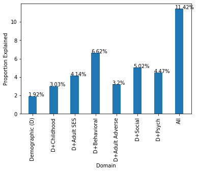

```python
# assign your bars to a variable so their attributes can be accessed
bars = plt.bar(coefA2.index, height=coefA2['r'], width=.4)
plt.xticks(rotation=90)
plt.xlabel('Domain')
plt.ylabel('Proportion Explained')
# access the bar attributes to place the text in the appropriate location
for bar in bars:
    yval = bar.get_height()
    plt.text(bar.get_x(), round(yval,2), str(round(yval,2))+'%')
```

# 5 ANALYSIS 3 - lasso regression

```python
from sksurv.linear_model import CoxnetSurvivalAnalysis
from sksurv.util import Surv
```

```python
m='rocc,fathersocc,Zfatherseduc,Zmotherseduc,fatherunemp,relocate,finhelp,sumCAE,ZwealthT,ZincomeT,everrent,evermedicaid,everfoodstamp,everunemployed,everfoodinsec,Zeduccat,Zrecentfindiff,Zneighsafety,Zneighcohesion,Zneighdisorder,vigactivityYN,modactivityYN,alcoholYN,sleepYN,eversmokeYN,currsmokeYN,sumadultAE,Zmajdiscrim,Zdailydiscrim,Znegchildren,Znegfamily,Znegfriends,Zposchildren,Zposfamily,nevermarried,everdivorced,Zagreeableness,Zangerin,Zangerout,Zanxiety,Zconscientiousness,Zcynhostility,Zextroversion,Zhopelessness,Zlifesatis,Zloneliness,Znegaffect,Zneuroticism,Zopenness,Zoptimism,Zperceivedconstraints,Zperceivedmastery,Zpessimism,Zposaffect,Zpurpose,Zreligiosity,maleYN,blackYN,hispanicYN,otherYN,migrantYN'
X=dfMort[m.split(',')]
y=Surv.from_dataframe('death', 'time', dfMort)
```

```python
cox_lasso = CoxnetSurvivalAnalysis(l1_ratio=1, alpha_min_ratio=0.00001)
cox_lasso.fit(X, y)
```

```
CoxnetSurvivalAnalysis(alpha_min_ratio=1e-05, alphas=None, copy_X=True,
                       fit_baseline_model=False, l1_ratio=1, max_iter=100000,
                       n_alphas=100, normalize=False, penalty_factor=None,
                       tol=1e-07, verbose=False)
```

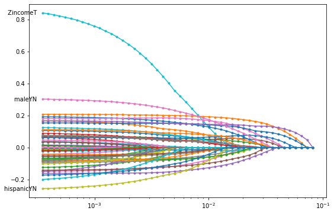

```python
cox_lasso = CoxnetSurvivalAnalysis(l1_ratio=1, alpha_min_ratio=0.00001)
cox_lasso.fit(X, y)
def plot_coefficients(coefs, n_highlight):
    _, ax = plt.subplots(figsize=(9, 6))
    n_features = coefs.shape[0]
    alphas = coefs.columns
    for row in coefs.itertuples():
        ax.semilogx(alphas, row[1:], ".-", label=row.Index)

    alpha_min = alphas.min()
    top_coefs = coefs.loc[:, alpha_min].map(abs).sort_values().tail(n_highlight)
    for name in top_coefs.index:
        coef = coefs.loc[name, alpha_min]
        plt.text(
            alpha_min, coef, name + "   ",
            horizontalalignment="right",
            verticalalignment="center"
        )

coefficients_lasso = pd.DataFrame(
    cox_lasso.coef_,
    index=X.columns,
    columns=np.round(cox_lasso.alphas_, 5)
)

plot_coefficients(coefficients_lasso, n_highlight=3)
```

```python
## this block need further exploration
import scipy, importlib, pprint, matplotlib.pyplot as plt, warnings
import glmnet_python
from glmnet import glmnet
from cvglmnet import cvglmnet; from cvglmnetCoef import cvglmnetCoef
from cvglmnetPlot import cvglmnetPlot; from cvglmnetPredict import cvglmnetPredict



fit = glmnet(x = np.array(X), y = np.array(dfMort[['time','death']]), family = 'cox')
```

# 6 ANALYSIS 4 - random forest

```python
%%time
from sksurv.ensemble import RandomSurvivalForest
m='+ rocc + fathersocc + Zfatherseduc + Zmotherseduc + ZwealthT + ZincomeT + everrent + evermedicaid +everunemployed +Zeduccat + Zrecentfindiff +Zneighcohesion +vigactivityYN + modactivityYN + alcoholYN + sleepYN + eversmokeYN + currsmokeYN +Zmajdiscrim + Zdailydiscrim +Znegfamily + Znegfriends +Zposfamily + nevermarried + everdivorced + Zagreeableness +Zconscientiousness +Zextroversion + Zhopelessness + Zlifesatis +Znegaffect + Zneuroticism + Zopenness + Zoptimism +Zperceivedmastery +Zposaffect + Zposfriends + Zpurpose + Zreligiosity + maleYN + blackYN + hispanicYN + otherYN + migrantYN +'
columns=re.findall(r' (\w*) +',str(m))
columns

estimator = RandomSurvivalForest(n_estimators=1000).fit(X, y)
```

[output not shown]

```python
%%time
import matplotlib.pyplot as plt
from sksurv.datasets import load_whas500
from sksurv.ensemble import RandomSurvivalForest


surv_funcs = estimator.predict_survival_function(X,assa=1)
type(surv_funcs)
```

[output not shown]

```python
for fn in surv_funcs:
    print(fn)
    plt.step(fn.x, fn(fn.x), where="post")

plt.ylim(0, 1)
plt.show()
```

[output not shown]

```python
dfMort['death'].value_counts()
```

```
0    10790
1     2821
Name: death, dtype: int64
```

```python
len(surv_funcs)
```

[output not shown]

[output not shown]